# بنام خدا

Hossein Vatani

April 1, 2016

# پسرفت چندگانه

## الف-پسرفت چندگانه

یک پسرفت با بیش از یک متغیر تشریح را ، پسرفت چندگانه گویند. سوای ساخت یک خط راست برای میانگین متغیر پاسخ توسط نمونه پسرفت، اینبار یک تابع از چند متغیر تشریح برای متغیر پاسخ خواهیم داشت. دستور ()lm برای این کاربرد نیز قابل استفاده است.دستور کلی ان بدین صورت است:

```r
lm(response ~ explanatory_1 + explanatory_2 + ... + explanatory_p)
```

*متاسفانه فایل های مربوط به این سری از مقاله ها یافت نشد،لذا داده هایی دیگر جهت مثال ها مورد استفاده قرار گرفته است.(پس بدنبال یکی بودن اعداد و ارقام مثال زیر با متن اصلی نباشید!)*

*نکته: ازین پس هرگاه در مثالی از داده هایی استفاده شد که منبع آن دردسترس نباشد ، ابتدای آن ذکر می کنم که: فایل موجود نبود.*

برای این مثال از داده های مربوط به خودرو که با نام mtcars در نرم افزار وجود دارد استفاده می کنیم.

```r
Car=mtcars[,c("mpg", "disp", "hp", "wt", "am")]
head(Car)
```

```
##                    mpg disp  hp    wt am
## Mazda RX4         21.0  160 110 2.620  1
## Mazda RX4 Wag     21.0  160 110 2.875  1
## Datsun 710        22.8  108  93 2.320  1
## Hornet 4 Drive    21.4  258 110 3.215  0
## Hornet Sportabout 18.7  360 175 3.440  0
## Valiant           18.1  225 105 3.460  0
```

```r
summary(Car)
```

```
##       mpg             disp             hp              wt
##  Min.   :10.40   Min.   : 71.1   Min.   : 52.0   Min.   :1.513
##  1st Qu.:15.43   1st Qu.:120.8   1st Qu.: 96.5   1st Qu.:2.581
##  Median :19.20   Median :196.3   Median :123.0   Median :3.325
##  Mean   :20.09   Mean   :230.7   Mean   :146.7   Mean   :3.217
##  3rd Qu.:22.80   3rd Qu.:326.0   3rd Qu.:180.0   3rd Qu.:3.610
##  Max.   :33.90   Max.   :472.0   Max.   :335.0   Max.   :5.424
##        am
##  Min.   :0.0000
##  1st Qu.:0.0000
##  Median :0.0000
##  Mean   :0.4062
##  3rd Qu.:1.0000
##  Max.   :1.0000
```

قبل از برازش و نمونه سازی تصویرسازی ای از اطلاعات را لازم است انجام دهیم تا دریافتی کلی از ارتباط اطلاعات را بدست آوریم.

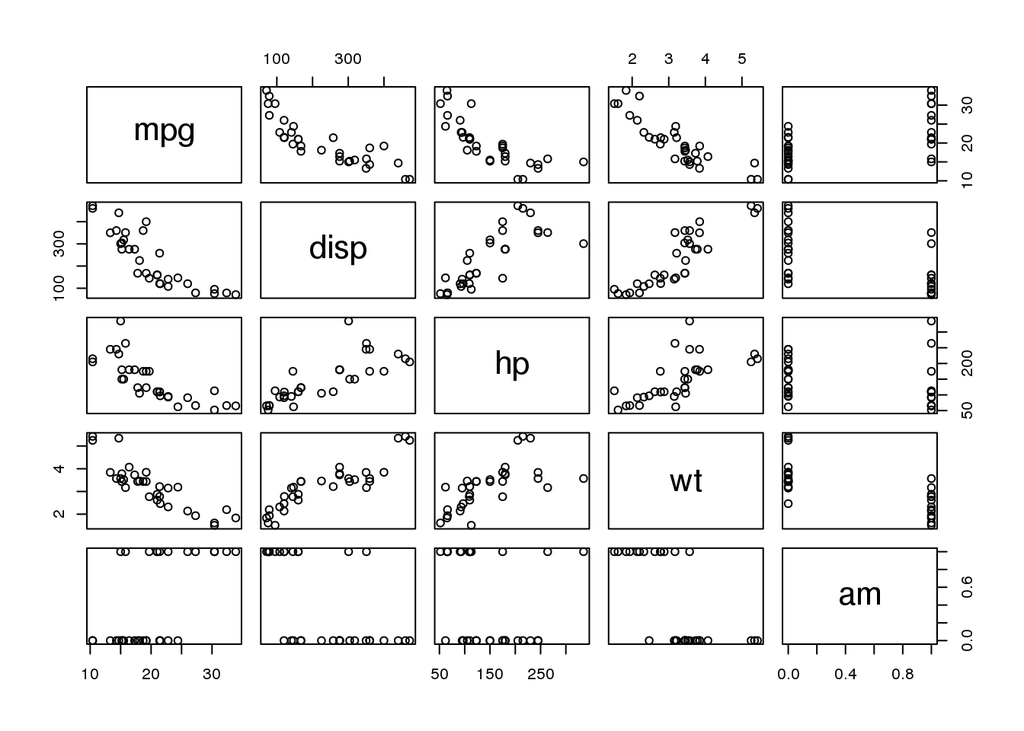

```r
plot(Car)
```

از ظاهر نمودار مشخص است که mpg با disp و hp و wt رابطه ای خطی دارد. ما جهت آزمایش نظر خودمان عامل am راکه ظاهرا بطور کامل بهم ناوابسته اند! را نیز در نمونه وارد می کنیم.

*توضیح متغیر ها را در رهنمای نرم افزار می توانید بیابید.*

```r
Fit1=lm(mpg ~ disp+ hp+ wt+ am, data = Car)
Fit1
```

```
##
## Call:
## lm(formula = mpg ~ disp + hp + wt + am, data = Car)
##
## Coefficients:
## (Intercept)         disp           hp           wt           am
##   34.209443     0.002489    -0.039323    -3.046747     2.159271
```

```r
summary(Fit1)
```

```
##
## Call:
## lm(formula = mpg ~ disp + hp + wt + am, data = Car)
##
## Residuals:
##     Min      1Q  Median      3Q     Max
## -3.4590 -1.6900 -0.3708  1.1301  5.5011
##
## Coefficients:
##              Estimate Std. Error t value Pr(>|t|)
## (Intercept) 34.209443   2.822826  12.119 1.98e-12 ***
## disp         0.002489   0.010377   0.240  0.81222
## hp          -0.039323   0.012434  -3.163  0.00384 **
## wt          -3.046747   1.157119  -2.633  0.01383 *
## am           2.159271   1.435176   1.505  0.14405
## ---
## Signif. codes:  0 '***' 0.001 '**' 0.01 '*' 0.05 '.' 0.1 ' ' 1
##
## Residual standard error: 2.581 on 27 degrees of freedom
## Multiple R-squared:  0.8402, Adjusted R-squared:  0.8166
## F-statistic:  35.5 on 4 and 27 DF,  p-value: 2.181e-10
```

با توجه به مقادیر P-Value متوجه می شویم که disp و am عاملهای مناسبی نیستند یا بعبارتی دیگر میانگین این دو عامل با میانگین mpg تفاوت معنی داری ندارد.لذا نمونه را دوباره بدون این دو بازسازی می کنیم.

```r
Fit2=lm(mpg ~ hp+ wt, data = Car)
Fit2
```

```
##
## Call:
## lm(formula = mpg ~ hp + wt, data = Car)
##
## Coefficients:
## (Intercept)           hp           wt
##    37.22727     -0.03177     -3.87783
```

```r
summary(Fit2)
```

```
##
## Call:
## lm(formula = mpg ~ hp + wt, data = Car)
##
## Residuals:
##    Min     1Q Median     3Q    Max
## -3.941 -1.600 -0.182  1.050  5.854
##
## Coefficients:
##             Estimate Std. Error t value Pr(>|t|)
## (Intercept) 37.22727    1.59879  23.285  < 2e-16 ***
## hp          -0.03177    0.00903  -3.519  0.00145 **
## wt          -3.87783    0.63273  -6.129 1.12e-06 ***
## ---
## Signif. codes:  0 '***' 0.001 '**' 0.01 '*' 0.05 '.' 0.1 ' ' 1
##
## Residual standard error: 2.593 on 29 degrees of freedom
## Multiple R-squared:  0.8268, Adjusted R-squared:  0.8148
## F-statistic: 69.21 on 2 and 29 DF,  p-value: 9.109e-12
```

## ب-آزمایش زیر مجموعه ای عامل های تشریحی بوسیله آزمون فیشر-قسمتی

برخی مواقع ، می خواهیم بدانیم که کدامیک از عامل های تشریح استفاده شده در نمونه پسرفت ، تاثیر معنی داری بر روی نمونه ندارند. برای اینگونه از آزمایش ها می توان از آزمون فیشر-قسمتی استفاده کرد؛بدین شرح که دو نمونه خطی که یکی دارای تمام عامل ها و دیگر فقط با عامل های مورد نظر می باشد ایجاد می کنیم و در نهایت از روش تحلیل پراکنش جهت تحلیل و نتیجه گیری استفاده می کنیم.

مثال-در مثال قبل می خواهیم بررسی کنیم که آیا واقعا تاثیر عاملهای disp و am بدون اهمیت می باشد یا خیر؟ از نتایج بدست آمده قبلی استفاده می کنیم.

```r
anova(Fit2,Fit1)
```

```
## Analysis of Variance Table
##
## Model 1: mpg ~ hp + wt
## Model 2: mpg ~ disp + hp + wt + am
##   Res.Df    RSS Df Sum of Sq      F Pr(>F)
## 1     29 195.05
## 2     27 179.91  2     15.14 1.1361 0.3359
```

با توجه به مقدار P-Value خروجی که برابر با ۰.۳۳ و بیشتر از فاصله اطمینان مورد نظر که .۰۵ است، می باشد، بوضوح می بینیم که دو عامل disp و am اختلاف معنی داری در نمونه ایجاد نمی کنند ولذا قابل صرفنظر مباشند(کاری که ما در همان مثال قبل انجام دادیم)۰

## ج-بازه های اطمینان و پیش بینی

مثال- می خواهیم مقدار mpg را برای خودرویی با hp برابر ۴۰۰ و wt برابر ۶ محاسبه کنیم.

```r
predict(Fit2,data.frame(hp=400,wt=6),interval="confidence") # جهت پیش بینی میانگین
```

```
##        fit       lwr      upr
## 1 1.251107 -2.428152 4.930366
```

```r
predict(Fit2,data.frame(hp=400,wt=6),interval="predict") # جهت پیش بینی مقدار
```

```
##        fit       lwr      upr
## 1 1.251107 -5.204175 7.706389
```